# EPIC2: TC all-SNPs vignette

Lingxuan Zhu

EPIC2 integrates scATAC-seq accessibility with GWAS summary statistics to test trait associations in cell groups. This vignette analyzes total cholesterol (**TC**) using all eligible SNPs in the example inputs.

# Install EPIC2

```r
if (!requireNamespace("devtools", quietly = TRUE)) install.packages("devtools")
devtools::install_github(
  "LingxuanZ/EPIC2",
  ref = "17a39bdab7d1f48b6c81fbf3cc4b074aa0a23c6e",
  upgrade = "never", build_vignettes = FALSE
)
```

The analysis also requires Seurat, Signac, BiocParallel, Rsamtools and presto. The repository provides an [analysis dependency installer](https://github.com/LingxuanZ/EPIC2/blob/main/scripts/install_dependencies.R).

# Example data

[Download the all-SNPs inputs (115.4 MB)](https://www.dropbox.com/scl/fi/waibphblujax44w9h0rvt/EPIC2_inputs_TC_SCZ_all_snps_raw.tar.gz?rlkey=hsg9z8hd94v1s2y4m5a8h8ck1&st=xy9u9vlc&dl=1).

This tutorial uses **a sampled subset of real scATAC-seq data**, together with real TC GWAS summary statistics and reference genotypes. The hg19/GRCh37 inputs contain **63,867 eligible TC SNPs** with reference genotypes from **503 individuals**, and **4,788 cells** in **24 tissue–cell-type groups** from **7 tissues**. The ATAC object contains **915,345 post-QC peaks**. Cells were sampled at up to 200 per group; all eligible TC SNPs were retained without SNP subsampling. The GWAS inputs have already undergone LD pruning and ambiguous-variant removal, and include variants with valid statistics, a reference-genotype match and overlap with accessible autosomal peaks.

The full data used in the manuscript are available on [Dropbox](https://www.dropbox.com/scl/fo/sryw79ywmy7gcty6pbm45/AOkzY5IFfC20oXzgY2vxoqM?rlkey=drrktk7uumyazina4woawdgl7&st=ino5s6so&dl=0).

| Input | Contents |
| --- | --- |
| `inputs_knit/data/atac.rds` | Peak counts, cell annotations and UMAP coordinates |
| `inputs_knit/data/gwas/TC.rds` | TC GWAS summary statistics |
| `inputs_knit/data/genotypes/TC.rds` | TC reference genotypes |
| `inputs_knit/data/fragments.tsv.gz` and its `.tbi` index | Indexed ATAC fragments |

Place the downloaded archive and the supplied config_knit.yml in your working directory, then extract the data. This configuration selects TC only.

```r
dir.create("inputs_knit", showWarnings = FALSE)
archive <- "inputs_knit/EPIC2_inputs_TC_SCZ_all_snps_raw.tar.gz"
if (!file.exists(archive)) {
  download.file(
    "https://www.dropbox.com/scl/fi/waibphblujax44w9h0rvt/EPIC2_inputs_TC_SCZ_all_snps_raw.tar.gz?rlkey=hsg9z8hd94v1s2y4m5a8h8ck1&st=xy9u9vlc&dl=1",
    archive, mode = "wb"
  )
}
stopifnot(identical(
  digest::digest(file = archive, algo = "sha256"),
  "b6172b11214ad4c43a6dd1d39132a4ca863ed5ebb894234baf70b0039add6275"
))
input_files <- grep("^data/", untar(archive, list = TRUE), value = TRUE)
untar(archive, files = input_files, exdir = "inputs_knit")
```

# Run the analysis

```r
library(EPIC2)
library(Seurat)
library(Signac)
config <- EPIC2::read_EPIC2_config("config_knit.yml", check_files = TRUE)
set.seed(config$parameters$seed)
```

The ATAC object has already passed QC. Attach the fragment file and save the checkpoint used by EPIC2. Fragment barcode validation is disabled because this file contains fragments only near the example loci.

```r
atac <- readRDS("inputs_knit/data/atac.rds")
fragment <- Signac::CreateFragmentObject(
  path = normalizePath("inputs_knit/data/fragments.tsv.gz"),
  cells = setNames(colnames(atac), colnames(atac)),
  validate.fragments = FALSE, verbose = FALSE
)
Signac::Fragments(atac[["ATAC"]]) <- NULL
Signac::Fragments(atac[["ATAC"]]) <- fragment
dir.create("output_knit/01_atac", recursive = TRUE, showWarnings = FALSE)
saveRDS(atac, "output_knit/01_atac/atac.qc.rds")
n_cells <- ncol(atac)
rm(atac, fragment)
invisible(gc())
```

Run GWAS harmonization, accessibility construction, local LD estimation, Wilcoxon rank-sum (WRS) scoring and the association models:

```r
withCallingHandlers(
  EPIC2::run_EPIC2(
    config,
    stages = c("gwas", "accessibility", "ld", "wrs", "model"),
    gwas_name = "TC"
  ),
  message = function(m) {
    cat(conditionMessage(m), "\n", file = "scripts_knit/analysis.log", append = TRUE)
    invokeRestart("muffleMessage")
  }
)
```

EPIC2 fits SNP accessibility, SNP WRS, peak accessibility and peak WRS components, then combines their P-values using ACAT. The run retains all 4,788 supplied cells. GWAS/reference QC retains 63,224 SNPs; the SNP and peak accessibility branches contain 58,390 and 57,713 features, respectively.

# Read the results

```r
results <- read.delim("output_knit/05_models/tissue_cell_type.cauchy_results.tsv")
results[, c("trait", "group", "p_cauchy", "p_cauchy_bh_within_trait")]
```

The six cell groups with the lowest TC ACAT P-values are shown below.

| Cell group | ACAT P | BH-adjusted P |
| --- | --- | --- |
| kidney_Ureteric bud cells | 0.000138 | 0.00297 |
| liver_Hepatoblasts | 0.000247 | 0.00297 |
| heart_Cardiomyocytes | 0.0255 | 0.137 |
| adrenal_Adrenocortical cells | 0.0275 | 0.137 |
| kidney_Vascular endothelial cells | 0.0286 | 0.137 |
| intestine_Intestinal epithelial cells | 0.139 | 0.556 |

`p_cauchy` is the Cauchy-combined P-value; `p_cauchy_bh_within_trait` is the Benjamini–Hochberg (BH)-adjusted P-value across tissue–cell-type groups for TC. Individual component estimates are saved in `tissue_cell_type.component_results.tsv`, and tissue-level results are in `tissue.cauchy_results.tsv`, under `output_knit/05_models/`.

# Generate and view the figures

```r
figure_manifest <- EPIC2::run_plot_stage(config, traits = "TC")
```

## ATAC data and QC

### ATAC QC metrics

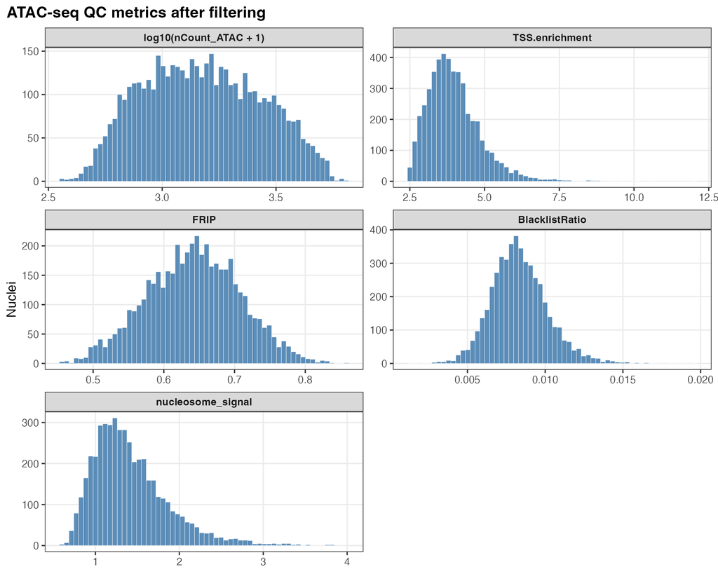

Distributions of the available cell-level QC metrics. PDF

### ATAC counts and TSS enrichment

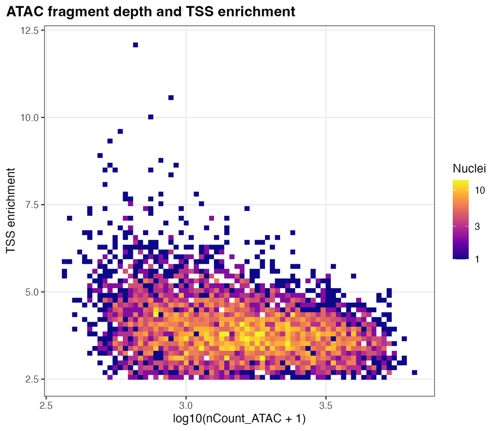

Relationship between ATAC counts and TSS enrichment. PDF

### Peak detection

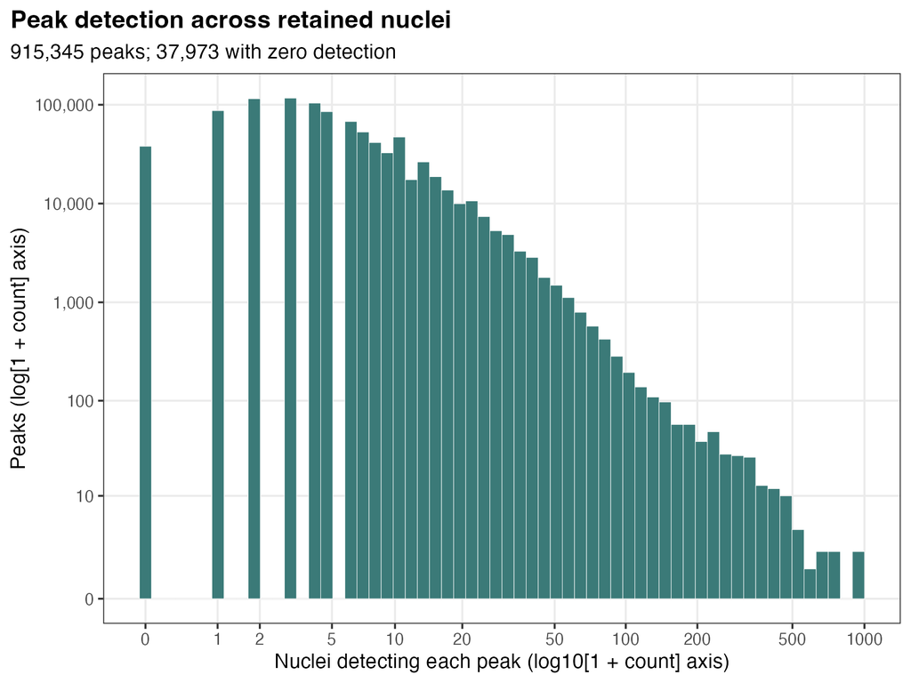

All peaks, including zero-detection peaks, are retained. The horizontal axis uses log10(1 + count) and the vertical axis uses log(1 + count); tick labels give the original counts. PDF

### Cell annotations

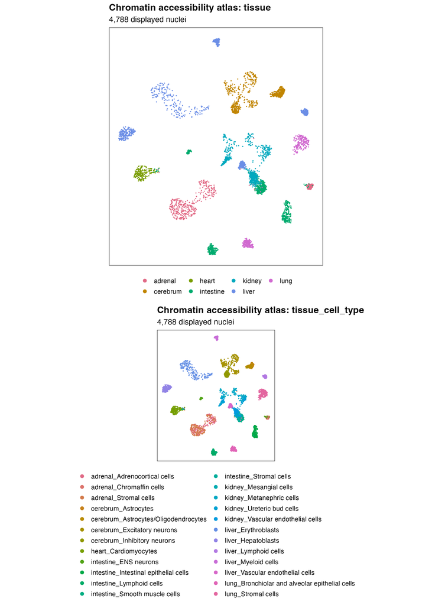

UMAP of all supplied cells, colored by tissue and tissue–cell-type group. PDF

## GWAS processing

### TC SNP retention

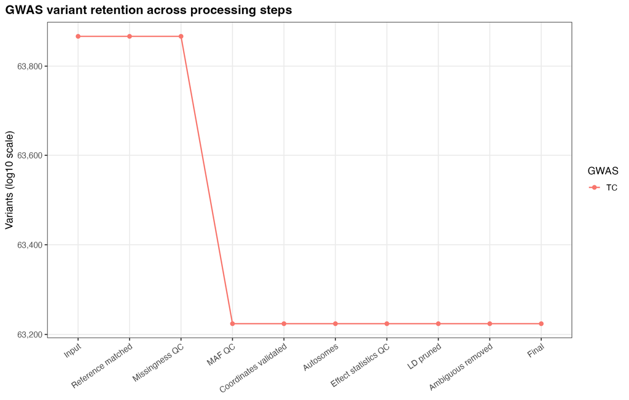

Numbers of TC SNPs retained during GWAS processing. PDF

### TC coordinate validation

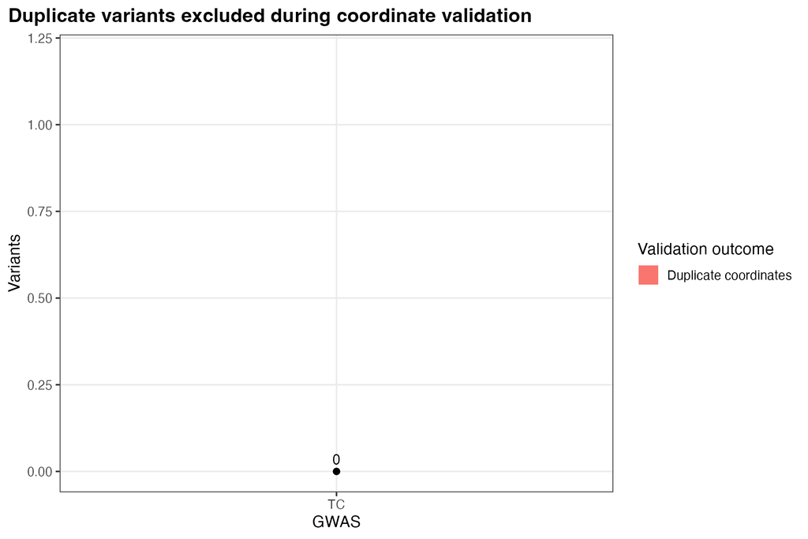

TC has 0 duplicate coordinates removed; the explicit zero is a valid QC result. PDF

## Accessibility

### Accessibility count distributions

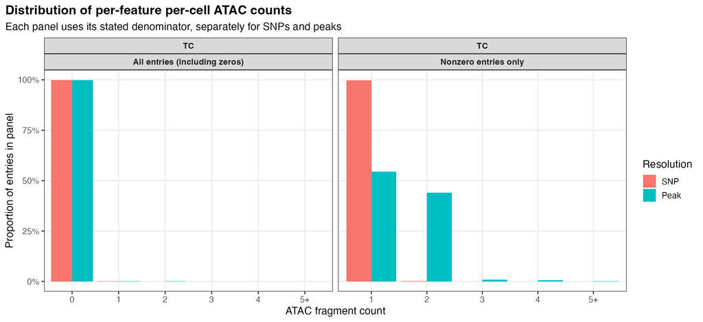

Left: all matrix entries, including zeros. Right: counts conditional on nonzero entries, with a separate denominator; SNP and peak features are both shown. PDF

### Feature detection

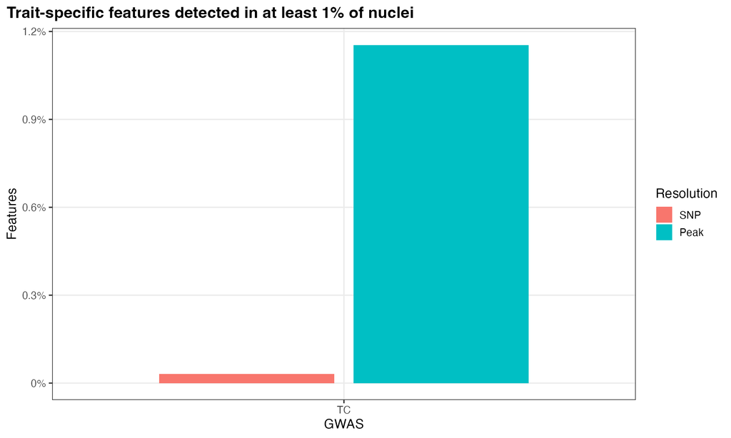

Proportion of TC features detected in at least 1% of cells. PDF

### SNP accessibility on UMAP

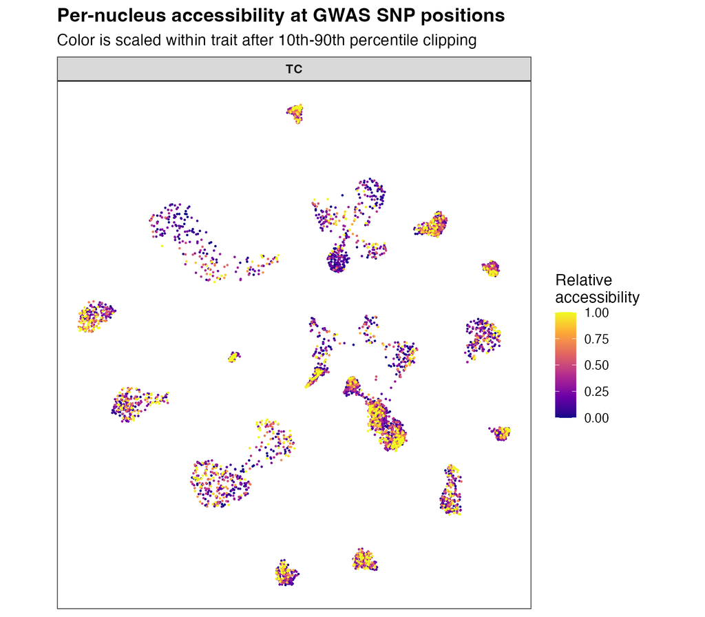

TC SNP accessibility counts on the cell embedding; colors use the package display scaling. PDF

### SNP accessibility by cell group

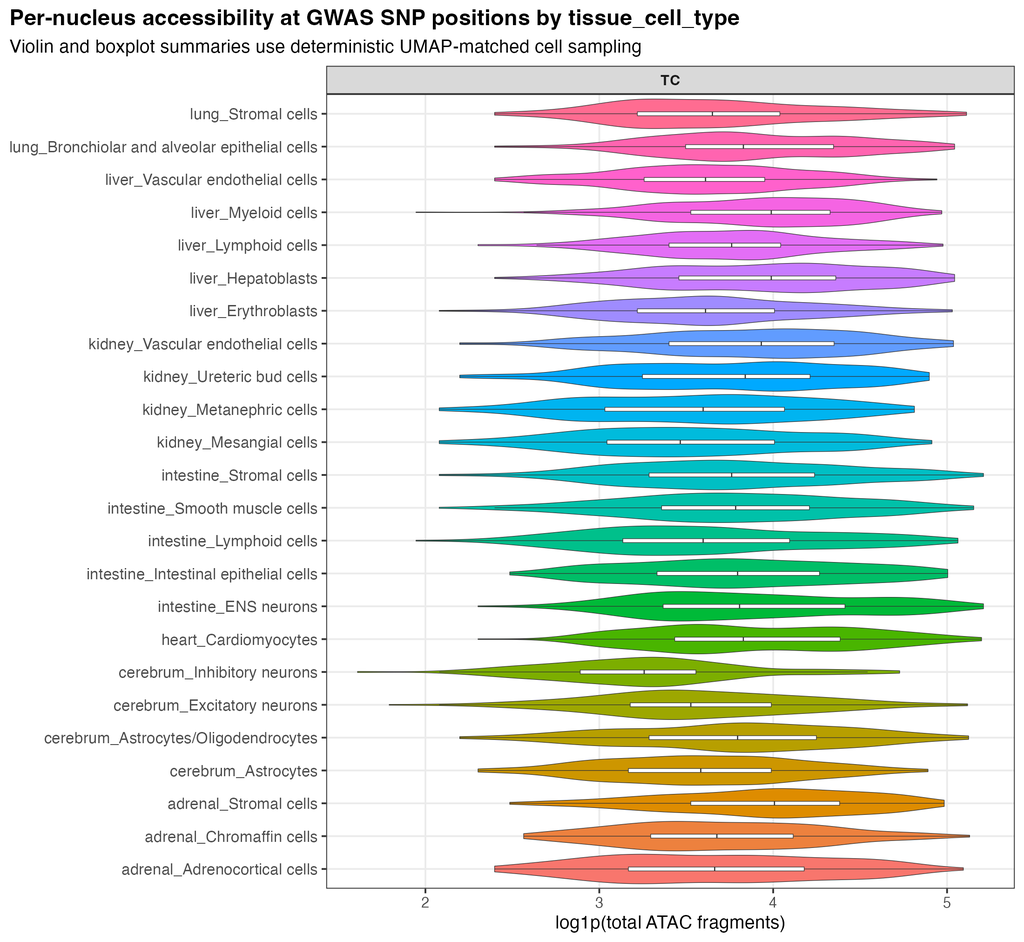

Distribution of TC SNP accessibility counts across cell groups. PDF

### Peak accessibility on UMAP

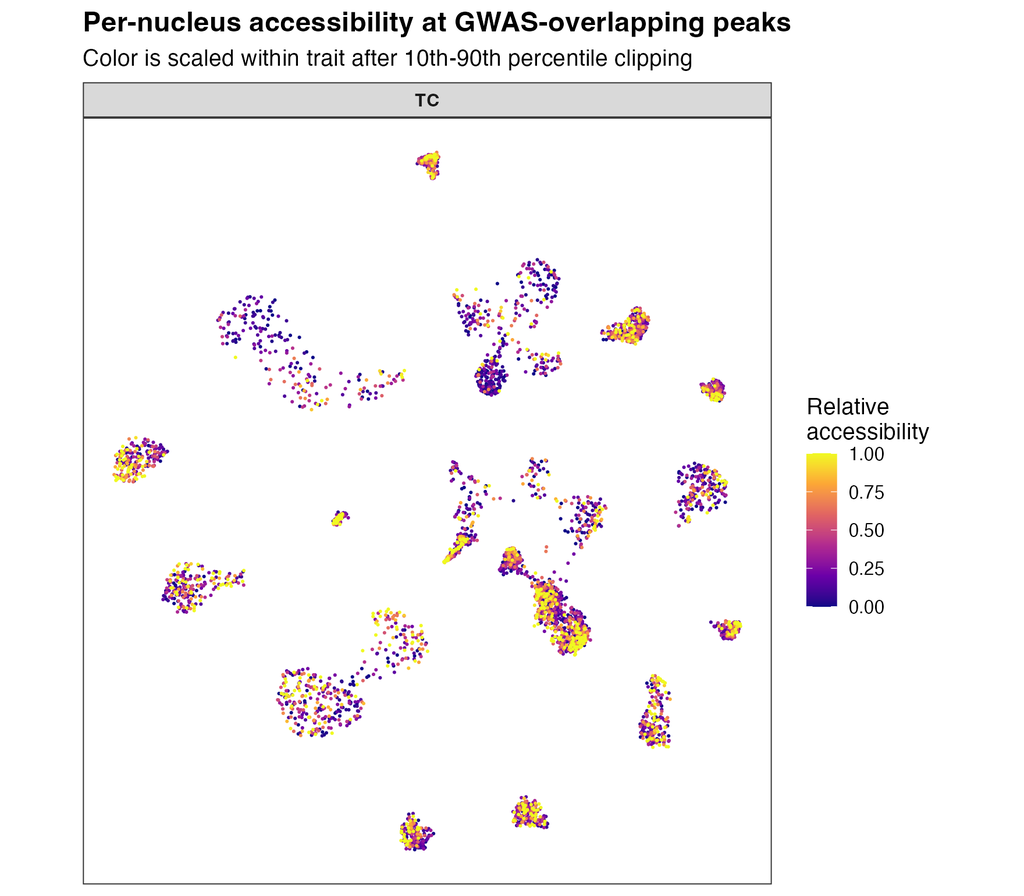

TC peak accessibility counts on the cell embedding; colors use the package display scaling. PDF

### Peak accessibility by cell group

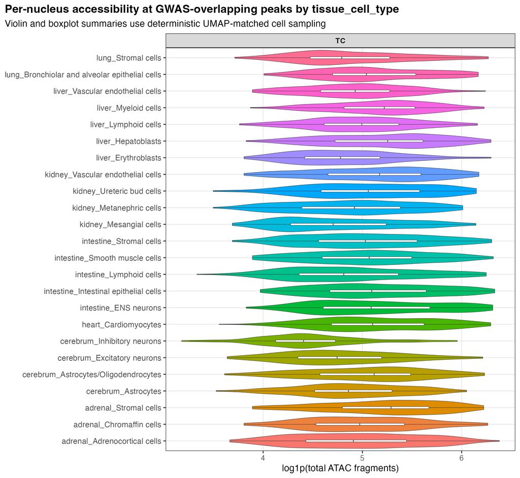

Distribution of TC peak accessibility counts across cell groups. PDF

## LD

### LD block sizes

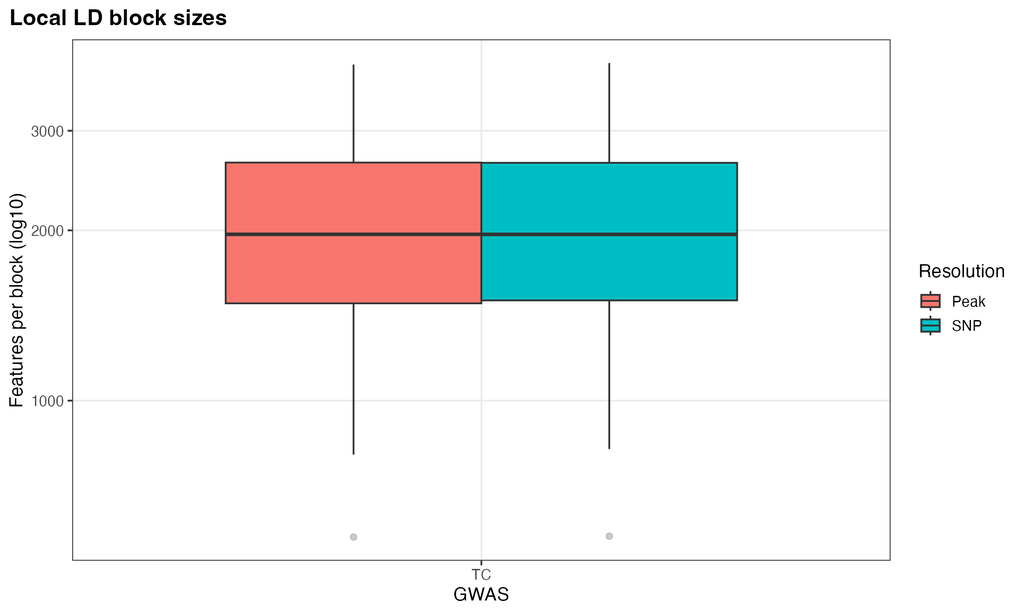

Sizes of the TC SNP and peak LD components. PDF

### SNP LD heatmap

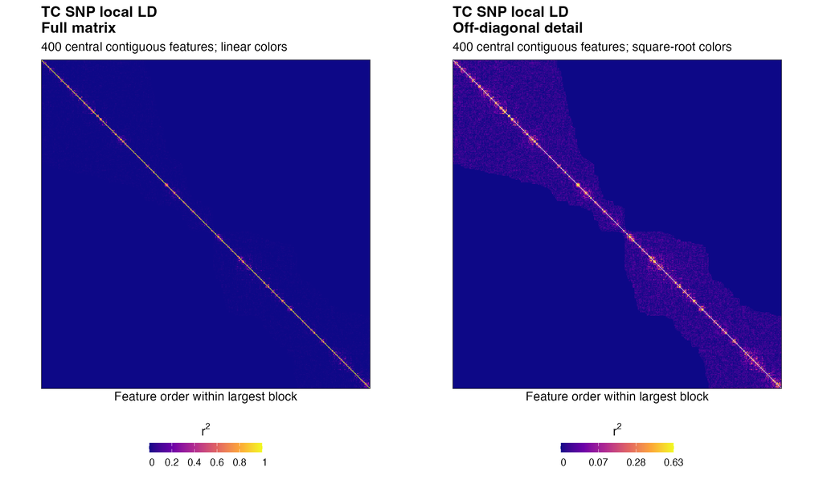

The same 400 contiguous SNPs, centered in the largest component, are shown in both panels. Left: full r² with linear colors. Right: diagonal masked and square-root colors to reveal off-diagonal structure. The full matrix is used for analysis. PDF

### Peak covariance heatmap

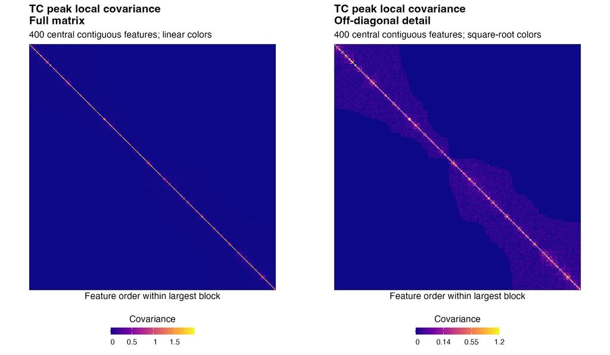

The same 400 contiguous peaks, centered in the largest component, are shown in both panels. Left: full covariance with linear colors. Right: diagonal masked and square-root colors. The full matrix is used for analysis. PDF

## WRS

### WRS summary by cell group

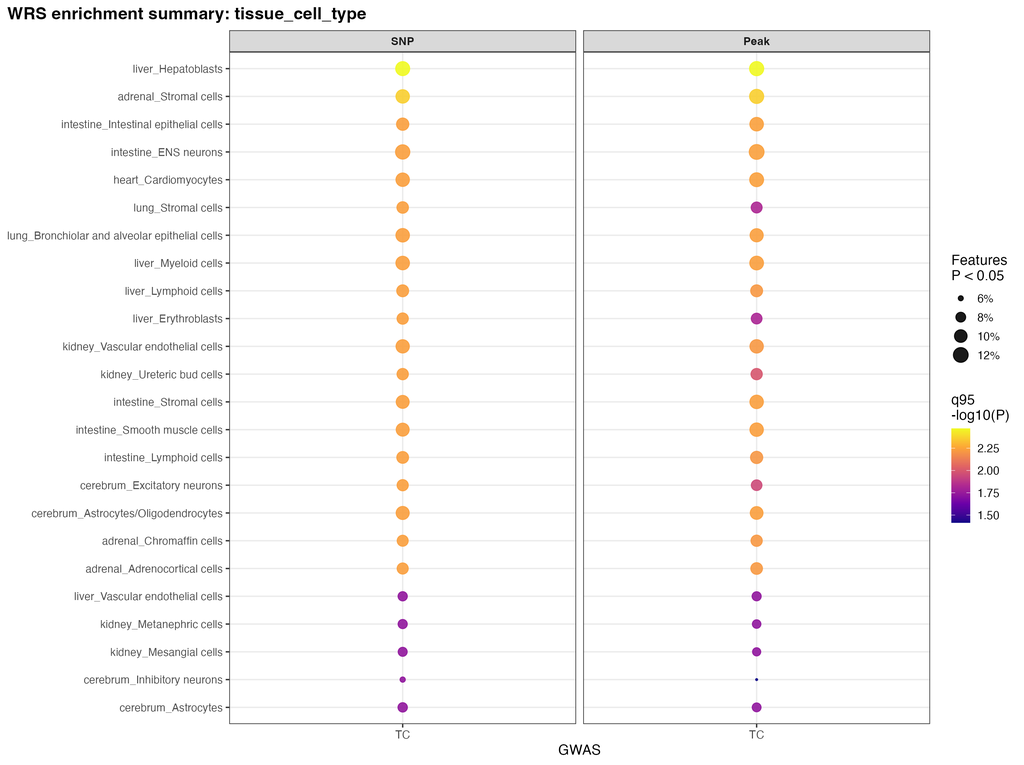

Point size shows the fraction of features with WRS P < 0.05; color shows the 95th percentile of −log10(P). PDF

### WRS summary by tissue

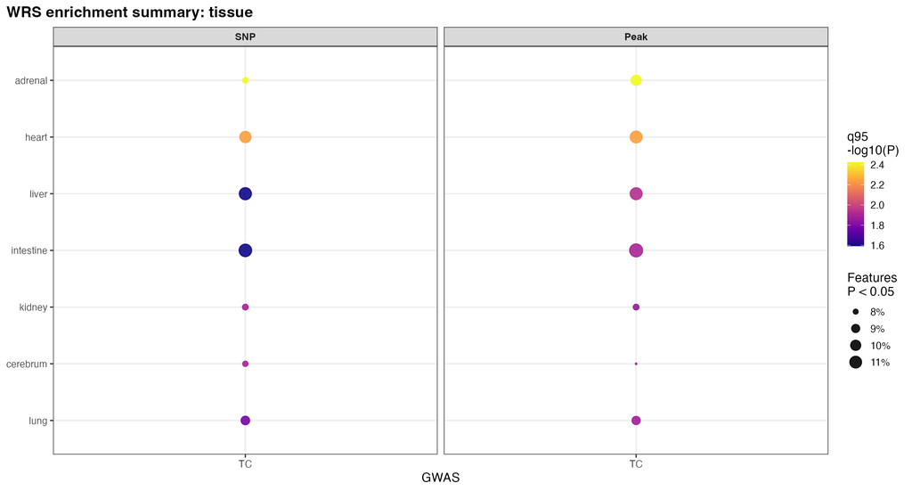

Point size shows the fraction of features with WRS P < 0.05; color shows the 95th percentile of −log10(P). PDF

### SNP WRS P-values by cell group

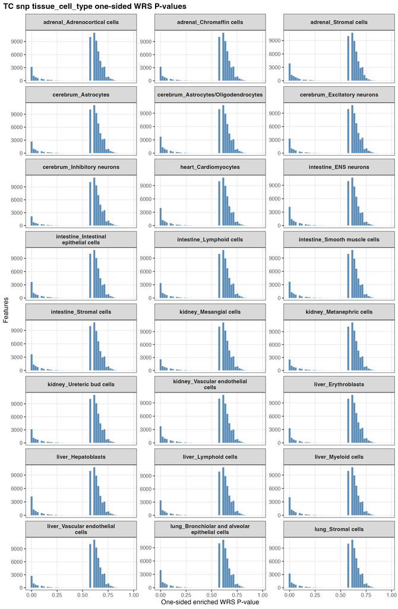

Distribution of one-sided WRS P-values for TC. PDF

### SNP WRS scores by cell group

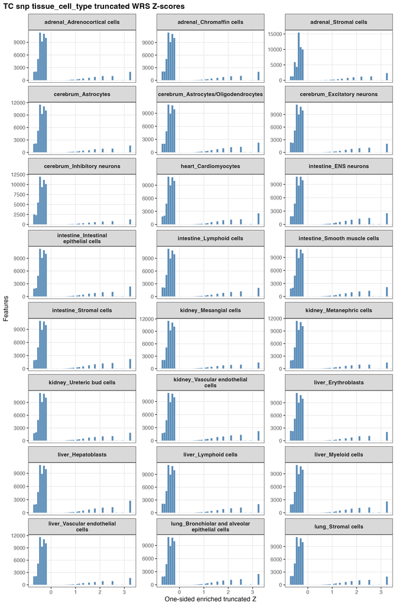

Distribution of truncated one-sided WRS normal scores for TC. PDF

### SNP WRS P-values by tissue

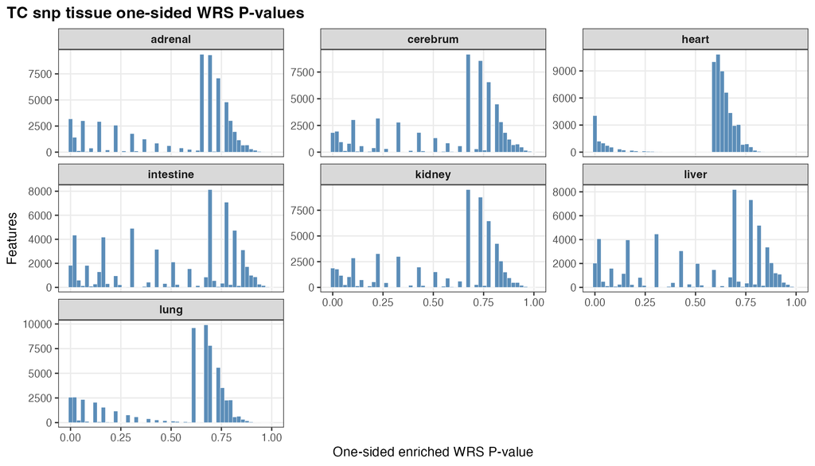

Distribution of one-sided WRS P-values for TC. PDF

### SNP WRS scores by tissue

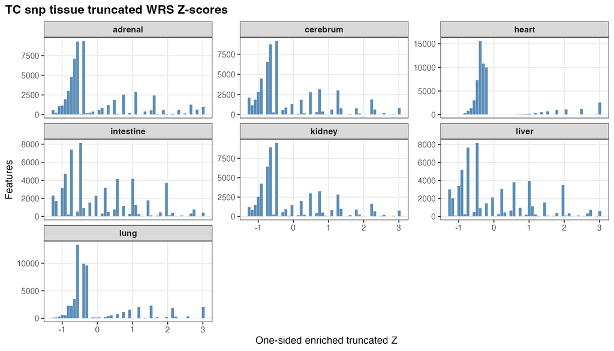

Distribution of truncated one-sided WRS normal scores for TC. PDF

### peak WRS P-values by cell group

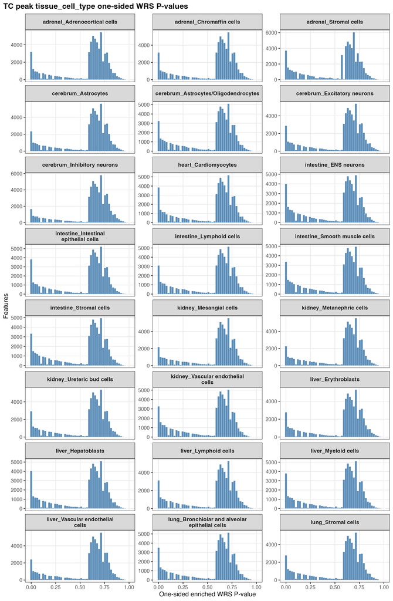

Distribution of one-sided WRS P-values for TC. PDF

### peak WRS scores by cell group

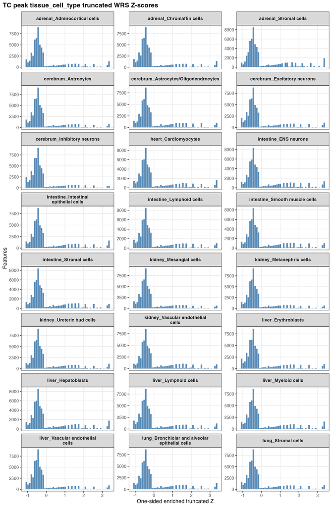

Distribution of truncated one-sided WRS normal scores for TC. PDF

### peak WRS P-values by tissue

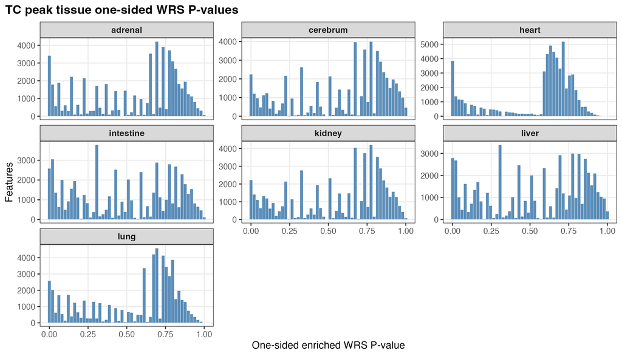

Distribution of one-sided WRS P-values for TC. PDF

### peak WRS scores by tissue

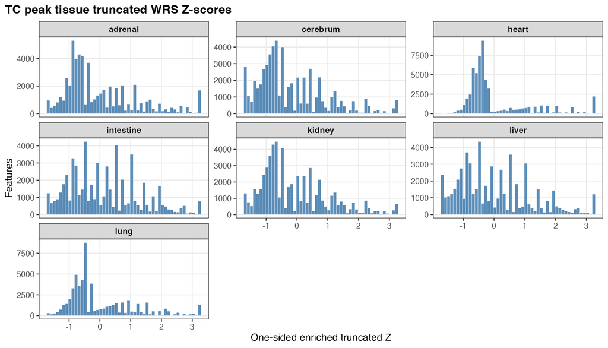

Distribution of truncated one-sided WRS normal scores for TC. PDF

### Top SNP features

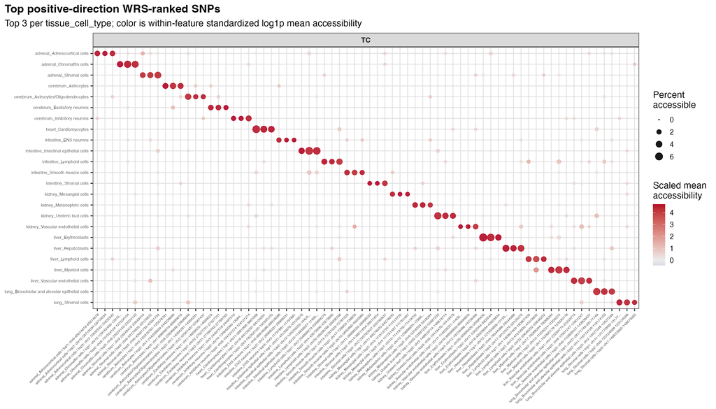

Accessibility of WRS-ranked SNP features for TC, selecting up to three features per cell group. PDF

### Top peak features

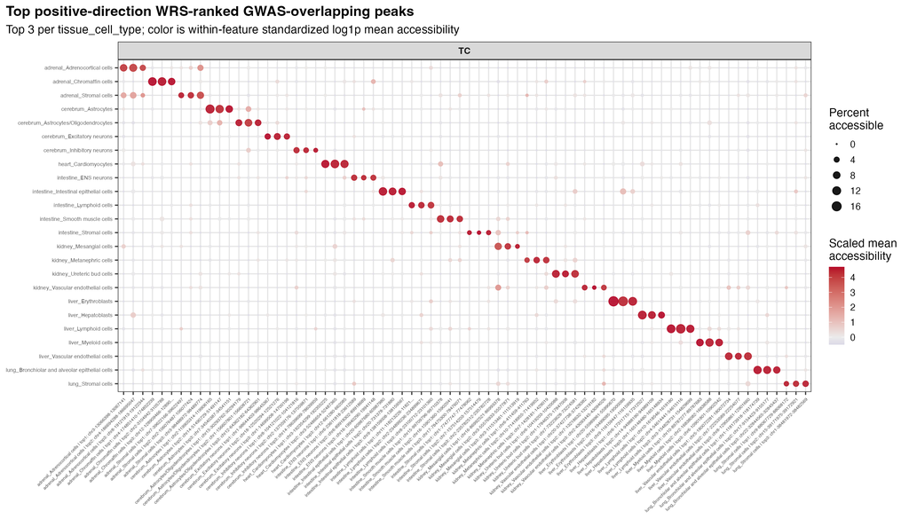

Accessibility of WRS-ranked peak features for TC, selecting up to three features per cell group. PDF

## Association results

### ACAT associations by cell group

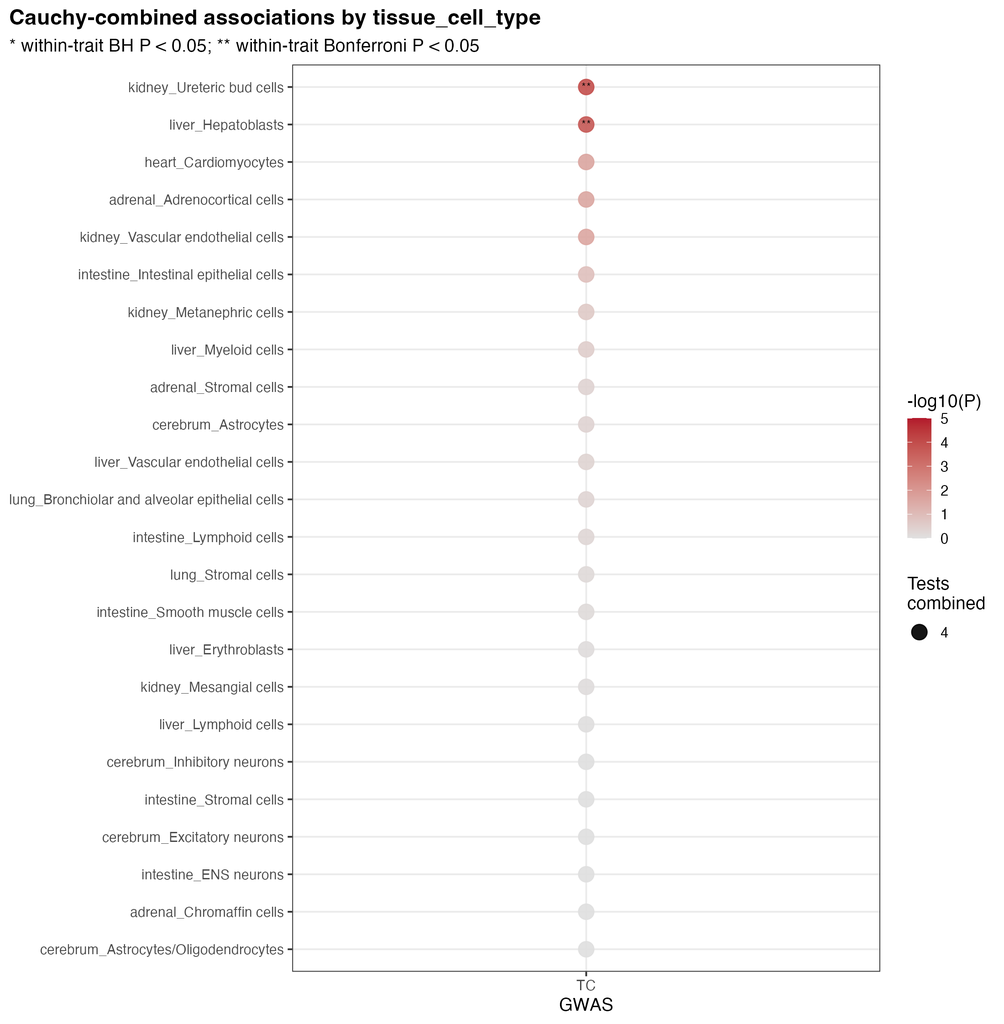

Color shows nominal −log10(P); point size shows the number of combined tests. * BH-adjusted P < 0.05; ** Bonferroni-adjusted P < 0.05. PDF

### Nominal component and ACAT tests by cell group

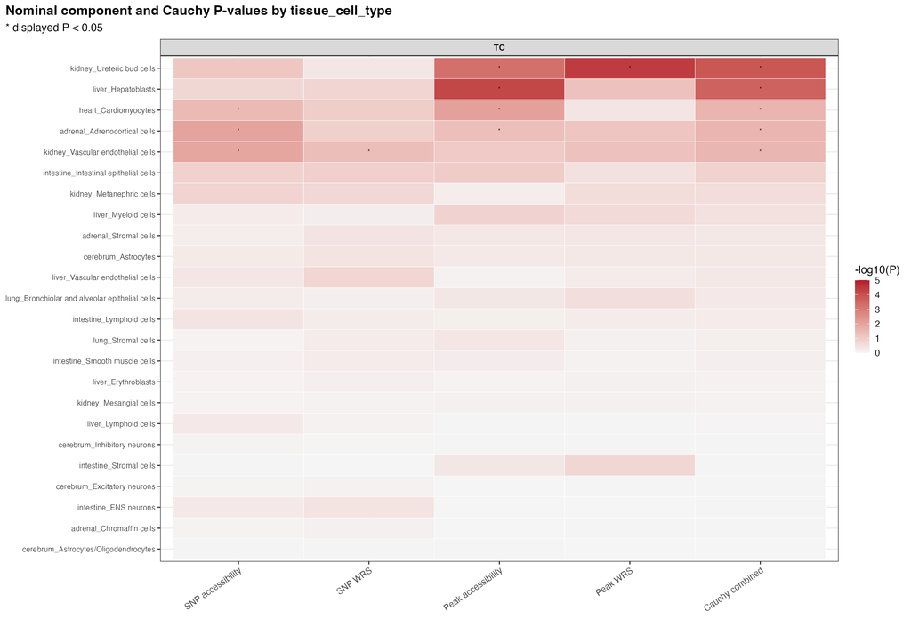

Nominal P-values for the four components and ACAT; stars indicate displayed P < 0.05. PDF

### BH-adjusted component and ACAT tests by cell group

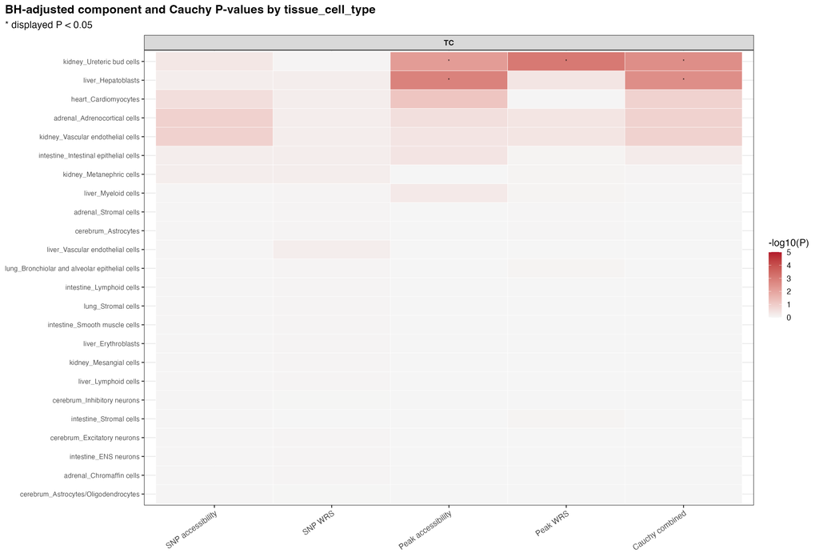

BH-adjusted P-values for the four components and ACAT; stars indicate displayed P < 0.05. PDF

### Bonferroni-adjusted component and ACAT tests by cell group

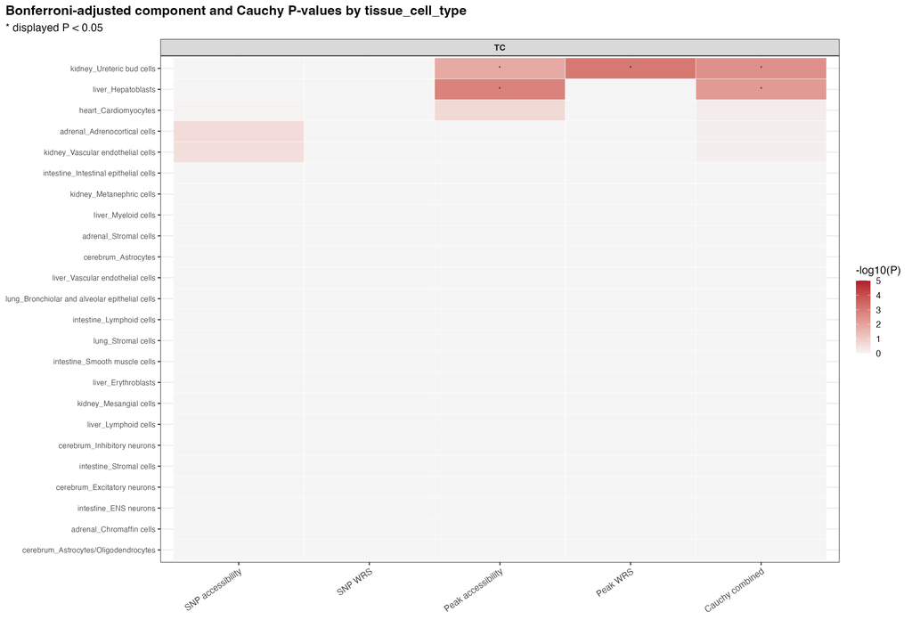

Bonferroni-adjusted P-values for the four components and ACAT; stars indicate displayed P < 0.05. PDF